# Diferensiasi Numerik

Metode Numerik (MTK0315)

Dr. Indira Puteri Kinasih

indiraputeri@uinmataram.ac.id

Universitas Islam Negeri Mataram

## Capaian Pembelajaran

Setelah mempelajari materi ini, mahasiswa diharapkan mampu:

1. menjelaskan konsep dasar diferensiasi numerik dan integrasi numerik;
2. menjelaskan ide dasar metode *forward difference*, *backward difference*, dan *central difference*;
3. menghitung turunan secara numerik menggunakan ketiga metode tersebut;
4. menjelaskan konsep galat pada diferensiasi numerik

## Pendahuluan

Dalam kalkulus, turunan dan integral biasanya dihitung secara analitik. Sebagai contoh,

$$f(x)=x^2$$

memiliki turunan

$$f'(x)=2x,$$

sedangkan

$$\int_0^2 x^2\,dx
=
\frac{8}{3}.$$

## Pendahuluan

- Namun, dalam banyak persoalan nyata, kita tidak selalu memiliki bentuk analitik dari suatu fungsi.
- Kita mungkin hanya memiliki:
  - data hasil pengamatan;
  - tabel nilai fungsi;
  - fungsi yang sangat kompleks;
  - fungsi yang sulit atau bahkan tidak dapat diintegralkan secara analitik.

Dalam kondisi tersebut, pendekatan numerik diperlukan. Secara umum:

> **Diferensiasi numerik** digunakan untuk mendekati nilai turunan suatu fungsi.

> **Integrasi numerik** digunakan untuk mendekati nilai integral suatu fungsi.

Ide utama kedua metode tersebut adalah mengganti persoalan matematika yang sulit dengan pendekatan yang dapat dihitung menggunakan operasi aritmetika sederhana.

## Turunan Numerik

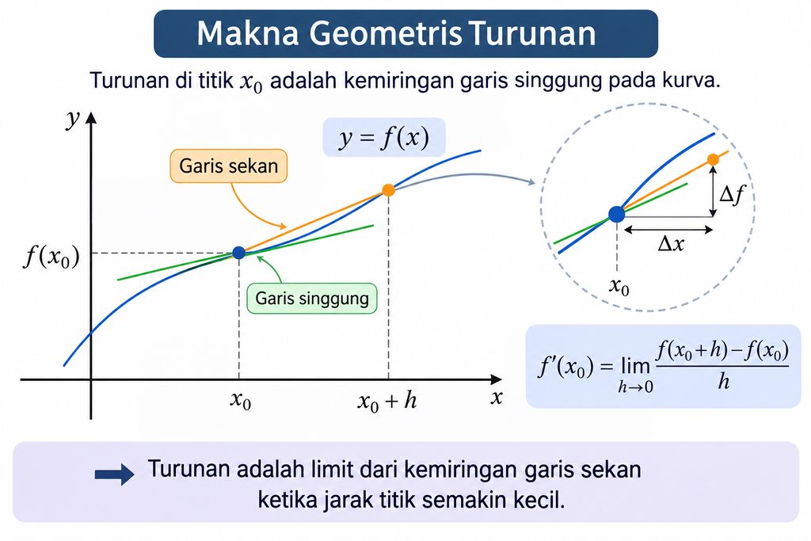

## Konsep Dasar Turunan

- Turunan pertama suatu fungsi didefinisikan sebagai

$$f'(x)
=
\lim_{h\rightarrow0}
\frac{f(x+h)-f(x)}{h}.$$

- Jika $h$ cukup kecil, maka limit tersebut dapat didekati dengan

$$f'(x)
\approx
\frac{f(x+h)-f(x)}{h}.$$

Inilah ide dasar diferensiasi numerik. Perhatikan bahwa

$$\frac{f(x+h)-f(x)}{h}$$

menggunakan dua titik, yaitu:

$$(x,f(x))$$

dan

$$(x+h,f(x+h)).$$

Secara geometris, nilai tersebut merupakan kemiringan garis yang menghubungkan dua titik pada kurva.

## Metode Turunan Numerik: makna geometris

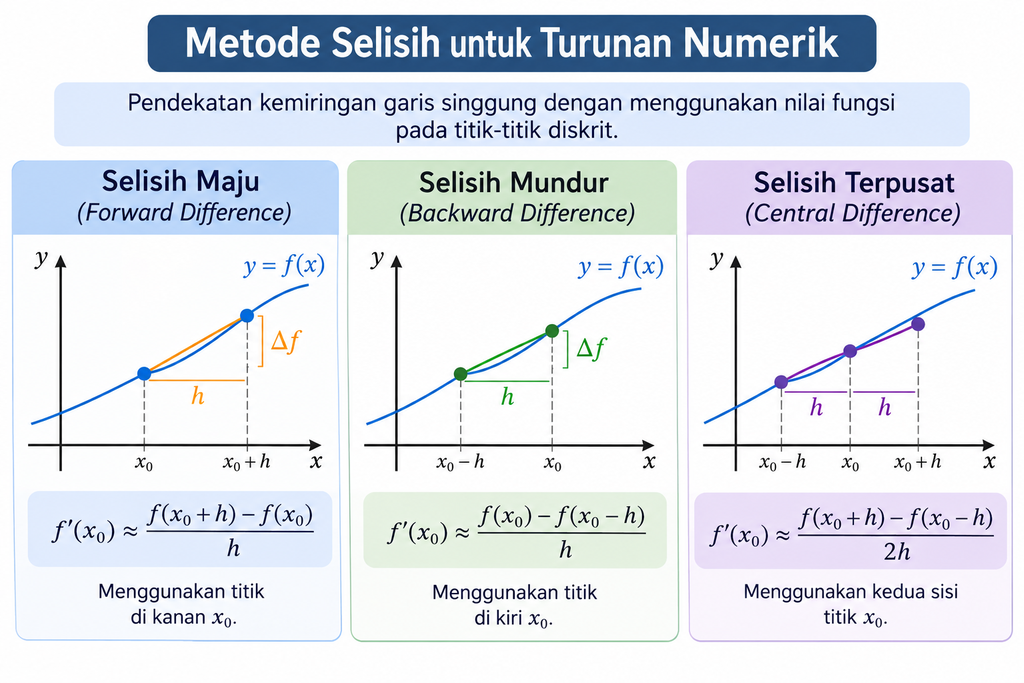

# Forward Difference

## Ide Dasar

Metode *forward difference* menggunakan nilai fungsi di titik $x$ dan titik di sebelah kanannya, yaitu $x+h$. Rumusnya:

$$\boxed{
f'(x)
\approx
\frac{f(x+h)-f(x)}{h}
}$$

Metode ini disebut *forward* karena kita bergerak maju dari $x$ menuju $x+h$.

## Contoh Manual

Diberikan

$$f(x)=x^2.$$

Tentukan pendekatan $f'(2)$ dengan $h=0.1.$. Nilai sebenarnya adalah

$$f'(x)=2x,$$

sehingga

$$f'(2)=4.$$

## Contoh manual

Sekarang gunakan metode *forward difference*. Diperoleh

$$f(2)=2^2=4$$

dan

$$f(2.1)=2.1^2=4.41.$$

Maka

$$f'(2)
\approx
\frac{f(2.1)-f(2)}{0.1}$$

$$=
\frac{4.41-4}{0.1}$$

$$=4.1.$$

Jadi pendekatan numeriknya adalah

$$\boxed{f'(2)\approx4.1}$$

sedangkan nilai sebenarnya adalah

$$f'(2)=4.$$

Galat absolut:

$$E=
|4.1-4|
=0.1.$$

# Backward Difference

## Ide Dasar

Berbeda dengan *forward difference*, metode *backward difference* menggunakan titik di sebelah kiri. Rumusnya:

$$\boxed{
f'(x)
\approx
\frac{f(x)-f(x-h)}{h}
}$$

Metode ini disebut *backward* karena kita bergerak mundur dari $x$ menuju $x-h$.

## Contoh Manual

Gunakan $f(x)=x^2$ untuk menghitung $f'(2)$ dengan

$$h=0.1.$$

Diketahui

$$f(2)=4$$

dan

$$f(1.9)=1.9^2=3.61.$$

Maka

$$f'(2)
\approx
\frac{f(2)-f(1.9)}{0.1}$$

$$=
\frac{4-3.61}{0.1}$$

$$=3.9.$$

Jadi

$$\boxed{f'(2)\approx3.9}$$

Galat absolut:

$$E=
|3.9-4|
=0.1.$$

# Central Difference

## Ide Dasar

Metode *central difference* menggunakan informasi dari kedua sisi titik $x$. Kita menggunakan:

$$x-h$$

dan

$$x+h.$$

Rumusnya:

$$\boxed{
f'(x)
\approx
\frac{f(x+h)-f(x-h)}{2h}
}$$

Metode ini biasanya lebih akurat daripada *forward difference* dan *backward difference* untuk nilai $h$ yang sama.

## Contoh Manual

Gunakan

$$f(x)=x^2$$

untuk menghitung $f'(2)$ dengan

$$h=0.1.$$

Diketahui:

$$f(2.1)=4.41$$

dan

$$f(1.9)=3.61.$$

Maka

$$f'(2)
\approx
\frac{f(2.1)-f(1.9)}
{2(0.1)}$$

$$=
\frac{4.41-3.61}{0.2}$$

$$=4.$$

Dengan demikian,

$$\boxed{f'(2)\approx4}$$

Hasil tersebut sama dengan nilai analitik.

# Perbandingan Tiga Metode

Ketiga metode dapat dirangkum sebagai berikut.

| Metode | Rumus | Orde galat |
| --- | --- | --- |
| Forward | $\frac{f(x+h)-f(x)}{h}$ | $O(h)$ |
| Backward | $\frac{f(x)-f(x-h)}{h}$ | $O(h)$ |
| Central | $\frac{f(x+h)-f(x-h)}{2h}$ | $O(h^2)$ |

Artinya, secara umum:

- *forward difference* memiliki galat yang sebanding dengan $h$;
- *backward difference* memiliki galat yang sebanding dengan $h$;
- *central difference* memiliki galat yang sebanding dengan $h^2$.

Karena $h^2$ mengecil lebih cepat daripada $h$, *central difference* biasanya memberikan hasil yang lebih akurat.

# Implementasi Diferensiasi Numerik dengan R

## Forward Difference

```r
f <- function(x) {
  x^2
}

x <- 2
h <- 0.1

forward <- (f(x + h) - f(x)) / h

forward
```

```
[1] 4.1
```

## Backward Difference

```r
backward <- (f(x) - f(x - h)) / h

backward
```

```
[1] 3.9
```

## Central Difference

```r
central <- (f(x + h) - f(x - h)) / (2*h)

central
```

```
[1] 4
```

## Nilai Analitik

```r
actual <- 2*x

actual

error_forward <- abs(forward - actual)
error_backward <- abs(backward - actual)
error_central <- abs(central - actual)

error_forward
error_backward
error_central
```

[output not shown]

## Menghitung galat

```r
error_forward <- abs(forward - actual)
error_backward <- abs(backward - actual)
error_central <- abs(central - actual)

error_forward
error_backward
error_central
```

[output not shown]

## Membuat fungsi R untuk diferensiasi numerik

```r
forward_difference <- function(f, x, h) {
  (f(x + h) - f(x)) / h
}
```

- Contoh penggunaan

```r
f <- function(x) {
  x^2
}

forward_difference(f, 2, 0.1)
```

[output not shown]

- **Tugas**: coba buat fungsi serupa untuk backward dan central difference!

## Eksperimen nilai $h$

Cobalah beberapa nilai:
$$h=0.5,\quad
0.1,\quad
0.05,\quad
0.01,\quad
0.001.$$

```r
f <- function(x) {
  x^2
}

x <- 2
actual <- 4

h_values <- c(0.5, 0.1, 0.05, 0.01, 0.001)

results <- data.frame(
  h = h_values,
  forward = sapply(
    h_values,
    function(h) forward_difference(f, x, h)
  ),
  backward = sapply(
    h_values,
    function(h) backward_difference(f, x, h)
  ),
  central = sapply(
    h_values,
    function(h) central_difference(f, x, h)
  )
)

results
```

[output not shown]